# Computing ecosystem respiration using response functions

Carlos A. Sierra

2023-10-27

Response functions can be used to compute the output signal produced as a result of an input signal passing through a system. `porce` includes functions to compute the impulse response function `irf` and the equilibrium response function `erf` of a model of class `lam`. Here we will use this functions to show how to compute respiration fluxes for the model fo Emanuel.

First we prepare the packages needed for this example and a color palette.

```r
library(porce)
library(SoilR)
library(expm)
library(RColorBrewer)
pal=brewer.pal(5, "Set2")
```

The Emanuel model is already available in `porce`, we only need to store it in an object and compute it’s equilibrium stock.

```r
EM<-EmanuelModel()
xss<-equilibriumStock(EM)
```

We will now create a function to perturb the values of GPP and increase it exponentially at a rate of 0.01 per year. The function `ut` returns the vector of inputs to the system for every simulation year, and the object `gpp` contains the numberical values

```r
yr<-seq(0,100,by=1/12)
ut<-function(t){exp(0.01*t) * EM@input}
gpp<-sapply(yr, FUN=function(t) sum(ut(t)))
```

The `irf` and `erf` functions return the impulse response and equilibrium response functions using as mail argument a model of class `lam`. The numerical evaluations of the functions can be obtained by the vectorized approach of R (apply family of functions), which is a convenient approach for fast computations.

```r
irfEM<-sapply(yr, irf(EM))
erfEM<-sapply(yr, erf(EM))
```

Although `irf` and `erf` produced the desired output, every call to these functions implies a number of computations on matrices (matrix exponential and multiplication), which are computationally expensive. A much simplier approach for the convolution of functions is to use instead a spline function of the numerical output. In the code below we use the spline functions of the gpp and irf to obtaine the respiration response of new inputs.

```r
recRe<-convolutionfun(t=yr,f=splinefun(yr, gpp), g=splinefun(yr, irfEM))
ReNew<-sapply(yr,recRe)
```

The existing stocks at $t=0$ are also respired, and we use the erf to obtain the release of C from these existing stocks.

```r
ReOld<-sum(xss)*erfEM
```

To evaluate the accuracy of these computations, we can also run a `SoilR` model with time dependent inputs and compute the respiration flux. In `SoilR` the models are solved using numerical solvers for a system of ordinary differential equations (ODE). This approach is also a little more computational expensive, but provides a highly accurate result.

```r
EM_SoilR<-Model(t=yr, A=EM@matrix, ivList = c(xss), inputFluxes = ut)
Rt<-getReleaseFlux(EM_SoilR)
```

Now we can visually compare the results from both approaches. We can see that the response function approach yields results that are indistinguishable from the traditional approach of solving systems of ODEs.

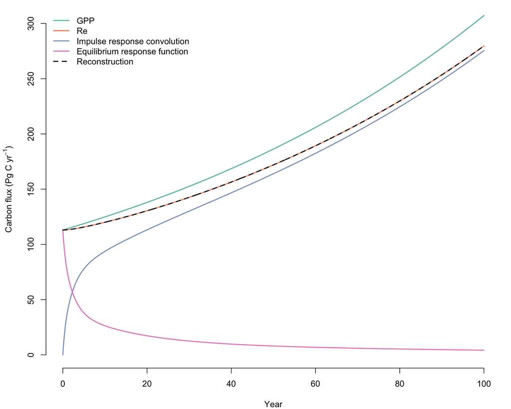

```r
par(mar=c(4,4.5,1,1), lwd=2)
plot(yr, gpp, type="l", ylim=c(0,300), xlim=c(0,100), xlab="Year",
     ylab=expression(paste("Carbon flux (Pg C ",yr^-1,")")), col=pal[1],bty="n")
lines(yr,rowSums(Rt),col=pal[2])
lines(yr,ReNew,col=pal[3])
lines(yr, ReOld, col=pal[4])
lines(yr, ReNew+ReOld, col=1, lty=2)
legend("topleft", c("GPP", "Re", "Impulse response convolution", "Equilibrium response function", "Reconstruction"),
       lty=c(rep(1,4),2),col=c(pal[-5],1),bty="n")
```

## Transit time and age distributions

The impulse response function and the transit time distribution of a linear autonomous model are equivalent. Similarly, the equilibrium response function and the system age distribution are equivalent. Therefore, the same computations above can be replaced by computations based on transit time and age distributions. These distributions can be easily obtained using `SoilR` functions `transitTime` and `systemAge`.

One important implication of this equivalence is that the respiration response of an ecosystem to a change in inputs can be obtained from the age of carbon in the respiration flux (transit time) and the age of carbon stored in an ecosystem.